# Window analysis with LM/Ms

Thejasvi Beleyur

Last Updated : 2024-12-16

This notebook will detail the use of bayesian linear models and mixed models to quantify the difference between single and multi-bat call properties. The final results are presented in the Parameter Summary. This notebook analyses the difference in:

1. Window received level
2. FM lower frequency
3. Dominant frequency range

The linear mixed models used in the following analysis used a non-informative prior. All intervals reported here are 95% highest posterior density compatibility intervals (Gelman and Greenland 2019; McElreath 2020). The compatibility interval corresponds to the estimate-interval that best explains the *current dataset*.

To read the summarised results straight away, proceed to the Summary Tables.

```r
library(arm)
library(coda)
library(lme4)
library(stringi)
library(stringr)
set.seed(82319)
# number of simulations to get from the posterior distribution
num_post <- 5000
# convenience function
get.hpd <- function(x,prange=0.95){HPDinterval(as.mcmc(x),prob=prange)}
get.map.coi <- function(x){c(mean(x), get.hpd(x))}
```

```r
# get annotations to remove just before splitting up the dataset into its component measurements
annots_to_remove <- read.csv('annotations_to_remove.csv')$annots_to_remove


annots.to.remove.present <- function(annotation.entry){
  # check if the row.entry has any of the substrings of the removable annotations
  remove.entry <- FALSE
  for (each in annots_to_remove){
    to.remove <- grepl(each, annotation.entry)
    if (isTRUE(to.remove))
    {
      remove.entry <- TRUE
    }
  }
  remove.entry
}

obs_splitmeasure_timestamp['rows_to_remove'] <- lapply(obs_splitmeasure_timestamp$video_annot_id, annots.to.remove.present)

# check to see if all the rows are valid after the filtering
all_valid_rows <- all(!obs_splitmeasure_timestamp$rows_to_remove)
if (isTRUE(all_valid_rows)){
  # don't do anything
} else{
    stop("There are some rows to be removed - this hasn't been coded in right now.")}


# RMS data
obs_reclevel <- subset(obs_splitmeasure_timestamp, measurement=='rms')
virt_reclevel <- subset(virt_splitmeasure, measurement=='rms')
obs_reclevel$dbrms <- 20*log10(obs_reclevel$value)
virt_reclevel$dbrms <- 20*log10(virt_reclevel$value)

# Lower frequency data
obs_lowerfreq <- subset(obs_splitmeasure_timestamp, measurement=='fm_terminal_freqs')
virt_lowerfreq <- subset(virt_splitmeasure, measurement=='fm_terminal_freqs')
# convert frequency to kHz
obs_lowerfreq$lowerfreqkhz <- obs_lowerfreq$value*10^-3
# remove a few aberrant zero's
obs_lowerfreq <- obs_lowerfreq[obs_lowerfreq$lowerfreqkhz>70,]

virt_lowerfreq$lowerfreqkhz <- virt_lowerfreq$value*10^-3
virt_lowerfreq <- virt_lowerfreq[virt_lowerfreq$lowerfreqkhz>70,]

# Dominant frequency data
obs_domfreq <- subset(obs_splitmeasure_timestamp, measurement=='dominant_frequencies')
virt_domfreq <- subset(virt_splitmeasure, measurement=='dominant_frequencies')
obs_domfreq$domfreq <- obs_domfreq$value*10^-3
virt_domfreq$domfreq <- virt_domfreq$value*10^-3

# - calculate the max-min range of dominant frequencies within one annotation audio.
calc.domf.range <- function(df){
          if (length(obs_domfreq$domfreq)>1){
                    c(max(df$domfreq)-min(df$domfreq),unique(df$group_status))
          }
          else {c(0,unique(df$group_status))}
          }
obs_domfrange.raw  <- by(obs_domfreq, obs_domfreq$video_annot_id, calc.domf.range)
obs_domfrange <- as.data.frame(do.call(rbind, obs_domfrange.raw))
colnames(obs_domfrange) <- c('domfrange','multi_bat')

# assign the centred posix minute to each annotation
obs_domfrange$video_annot_id <- row.names(obs_domfrange)
obs_domfrange$centred_posix_minute <- NA
i = 1
for (each in row.names(obs_domfrange))
  {
  obs_domfrange$centred_posix_minute[i] <- unique(subset(obs_domfreq, video_annot_id==each)$centred_posix_minute)
  i <- i+1
  }
colnames(obs_domfrange)[2] <- 'group_status'
obs_domfrange$group_status <- as.factor(obs_domfrange$group_status)
obs_domfrange$rechour <- unlist(lapply(obs_domfrange$video_annot_id,get_rechour))


virt_domfrange.raw  <- by(virt_domfreq, virt_domfreq$video_annot_id, calc.domf.range)
virt_domfrange <- as.data.frame(do.call(rbind, virt_domfrange.raw))
virt_domfrange$video_annot_id <- row.names(virt_domfrange)
row.names(virt_domfrange) <- NULL
colnames(virt_domfrange) <- c('domfrange','group_status','video_annot_id')
virt_domfrange$group_status <- 2
virt_domfrange$rechour <- unlist(lapply(virt_domfrange$video_annot_id,get_rechour,virtual=TRUE))
```

## Received level : RMS

And now build the model that will account for the expected auto-correlation in segments, windows and time in general. This model has $\sqrt{dBrms}$ as the outcome and `group_status` as the fixed effect, with `recording hour` and `video annotation ID` as random intercepts.

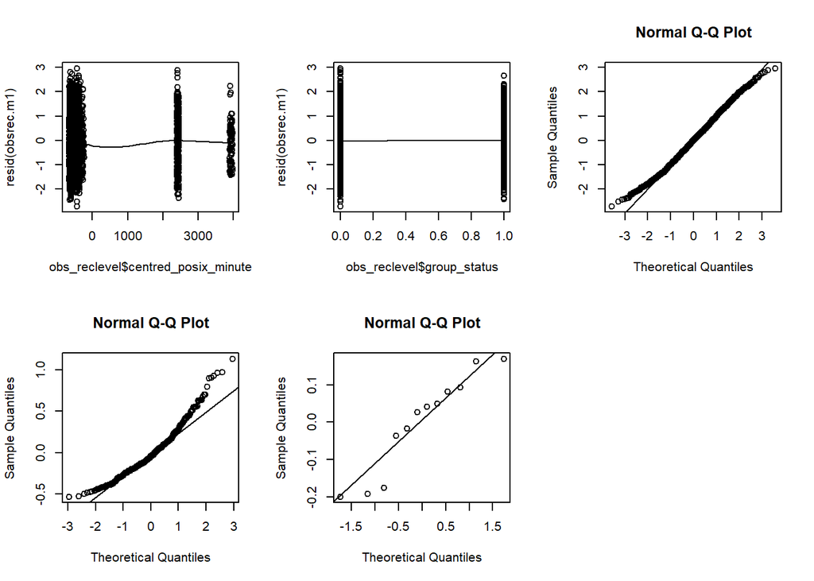

```r
# all dbrms are negative values -- convert them to +ve to allow square rooting
obs_reclevel$sqrtdbrms <- sqrt(abs(min(obs_reclevel$dbrms))+obs_reclevel$dbrms)

obsrec.m1 <- lmer(sqrtdbrms ~ group_status + (1|rechour)+(1|video_annot_id), data=obs_reclevel)

raneffects.m1 <- ranef(obsrec.m1)$video_annot_id$'(Intercept)'
raneffects2.m1 <- ranef(obsrec.m1)$rechour$'(Intercept)'
par(mfrow=c(2,3))
scatter.smooth(obs_reclevel$centred_posix_minute,resid(obsrec.m1))
scatter.smooth(obs_reclevel$group_status,resid(obsrec.m1))
qqnorm(resid(obsrec.m1));qqline(resid(obsrec.m1))
qqnorm(raneffects.m1);qqline(raneffects.m1)
qqnorm(raneffects2.m1);qqline(raneffects2.m1)
```

```r
obsrec.m1.sim <- sim(obsrec.m1, n.sim=num_post)
m1.hpd.fixefs <- apply(fixef(obsrec.m1.sim),2,get.hpd)

# remember to square the predictions to get the units back to dB from sqrt(dB)
single.reclevel <- fixef(obsrec.m1.sim)[,1]^2-abs(min(obs_reclevel$dbrms))
multi.reclevel <- (fixef(obsrec.m1.sim)[,1]+fixef(obsrec.m1.sim)[,2])^2- abs(min(obs_reclevel$dbrms))
hpd.single.reclevel <- round(get.hpd(single.reclevel),0)
hpd.multi.reclevel <- round(get.hpd(multi.reclevel),0)
# the final expected multi-single rec-level difference in dB
hpd.multi.single.diffrec <- round(get.hpd(multi.reclevel-single.reclevel),1)
```

The mean received level of single-bat windows is between -33to-32 dB, and multi-bat windows is -33 to -32 dB. The difference betweeen multi-single bat windows is between -0.3 to 0.9 dB.

### with virtual bat audio

```r
obs_reclevel_subset <- obs_reclevel[,c('segment_number','dbrms','sqrtdbrms','group_status','rechour','video_annot_id')]
obs_reclevel_subset$group_status <- as.factor(obs_reclevel_subset$group_status*1)
virt_reclevel_subset <- virt_reclevel[,c('segment_number','dbrms','rechour','video_annot_id')]

virt_reclevel_subset$sqrtdbrms <- sqrt(abs(min(obs_reclevel$dbrms))+virt_reclevel_subset$dbrms)
virt_reclevel_subset$group_status <- as.factor(2)
obsvirt_reclevel <- rbind(obs_reclevel_subset, virt_reclevel_subset)

write.csv(obsvirt_reclevel, 'obsvirt_reclevel.csv')
```

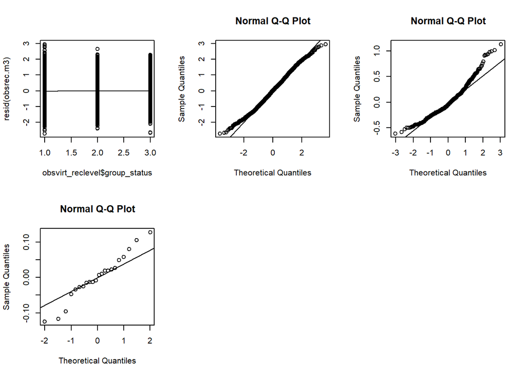

```r
obsrec.m3 <- lmer(sqrtdbrms ~ group_status + (1|rechour) +(1|video_annot_id), data=obsvirt_reclevel)
raneffects.m3 <- ranef(obsrec.m3)$video_annot_id$'(Intercept)'
raneffects2.m3 <- ranef(obsrec.m3)$rechour$'(Intercept)'
par(mfrow=c(2,3))
#scatter.smooth(obsvirt_reclevel$centred_posix_minute,resid(obsrec.m3))
scatter.smooth(obsvirt_reclevel$group_status,resid(obsrec.m3))
qqnorm(resid(obsrec.m3));qqline(resid(obsrec.m3))
qqnorm(raneffects.m3);qqline(raneffects.m3)
qqnorm(raneffects2.m3);qqline(raneffects2.m3)
```

The model assumptions are met okay’ly well - though the normality of the random effects is definitely a bit off.

```r
obsrec.m3.sim <- sim(obsrec.m3, n.sim=num_post)
m3.hpd.fixefs <- apply(fixef(obsrec.m3.sim),2,get.hpd)

# remember to square the predictions to get the units back to dB from sqrt(dB)
single.reclevel <- fixef(obsrec.m3.sim)[,1]^2-abs(min(obs_reclevel$dbrms))
multi.reclevel <- (fixef(obsrec.m3.sim)[,1]+fixef(obsrec.m3.sim)[,2])^2- abs(min(obs_reclevel$dbrms))
virt.reclevel <- (fixef(obsrec.m3.sim)[,1]+fixef(obsrec.m3.sim)[,3])^2- abs(min(obs_reclevel$dbrms))
hpd.single.reclevel <- round(get.hpd(single.reclevel),0)
hpd.multi.reclevel <- round(get.hpd(multi.reclevel),0)
hpd.virt.reclevel <- round(get.hpd(virt.reclevel),0)
# the final expected multi-single rec-level difference in dB
hpd.multi.single.diffrec <- round(get.hpd(multi.reclevel-single.reclevel),1)
hpd.virt.multi.diffrec <- round(get.hpd(multi.reclevel-virt.reclevel),1)


# shape into the table format
multisingle_reclevel_mapcoi <- round(get.map.coi(multi.reclevel-single.reclevel),1)
multivirtmulti_reclevel_mapcoi <- round(get.map.coi(multi.reclevel-virt.reclevel),1)

table_multisingle_reclevel <- c('Multi-Single','Received level (dB RMS)',multisingle_reclevel_mapcoi,'-','-','-')
table_multivirtmulti_reclevel <- c('Multi-Virtual multi','Received level (dB RMS)',multivirtmulti_reclevel_mapcoi,'-','-','-')
table_reclevel <- rbind(table_multisingle_reclevel,table_multivirtmulti_reclevel )

# plot data mean MAP and CoI
plotdata_reclevel_meancoi <- data.frame(t(unlist(lapply(list(single.reclevel, multi.reclevel, virt.reclevel), get.map.coi ))))
colnames(plotdata_reclevel_meancoi) <- c('single-map','single-95hpd-lower','single-95hpd-upper',
                                         'multi-map','multi-95hpd-lower','multi-95hpd-upper',
                                         'virtmulti-map','virtmulti-95hpd-lower','virtmulti-95hpd-upper')
rownames(plotdata_reclevel_meancoi) <- c('rec-level')
```

## FM lower frequency

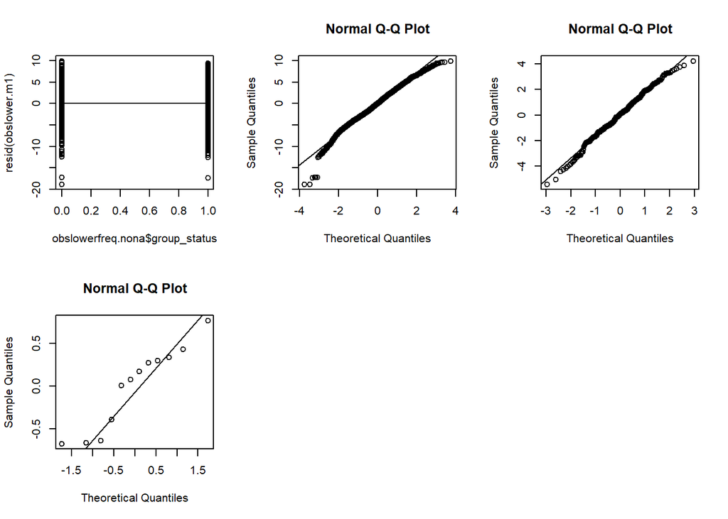

```r
obslowerfreq.nona <- obs_lowerfreq[!is.na(obs_lowerfreq$lowerfreqkhz),]
obslower.m1 <- lmer(lowerfreqkhz ~ group_status + (1|rechour) +(1|video_annot_id), data=obslowerfreq.nona)
raneffects.m1 <- ranef(obslower.m1)$video_annot_id$'(Intercept)'
raneffects2.m1 <- ranef(obslower.m1)$rechour$'(Intercept)'


par(mfrow=c(2,3))
scatter.smooth(obslowerfreq.nona$group_status,resid(obslower.m1))
qqnorm(resid(obslower.m1));qqline(resid(obslower.m1))
qqnorm(raneffects.m1);qqline(raneffects.m1)
qqnorm(raneffects2.m1);qqline(raneffects2.m1)
```

```r
obslower.m1.sim <- sim(obslower.m1, n.sim=num_post)

lowerm2.hpd.fixefs <- apply(fixef(obslower.m1.sim),2,get.hpd)

single.lower <- fixef(obslower.m1.sim)[,1]
multi.lower <- fixef(obslower.m1.sim)[,1]+fixef(obslower.m1.sim)[,2]
hpd.single.lower <- round(get.hpd(single.lower),2)
hpd.multi.lower <- round(get.hpd(multi.lower),2)
hpd.multi.single.lowerdiff <- round(get.hpd(multi.lower-single.lower),2)
hpd.multi.single.lower.ratio <- round(get.hpd(multi.lower/single.lower),3)
```

Results for *all* data suggest a general decrease of between -0.84-0.3 kHz of multi-bat FM lower frequencies in comparison to single bat calls. This corresponds to a relative ratio of between 0.991-1.003 with reference to single bat calls. Overall, it suggests a great similarity in FM lower frequencies.

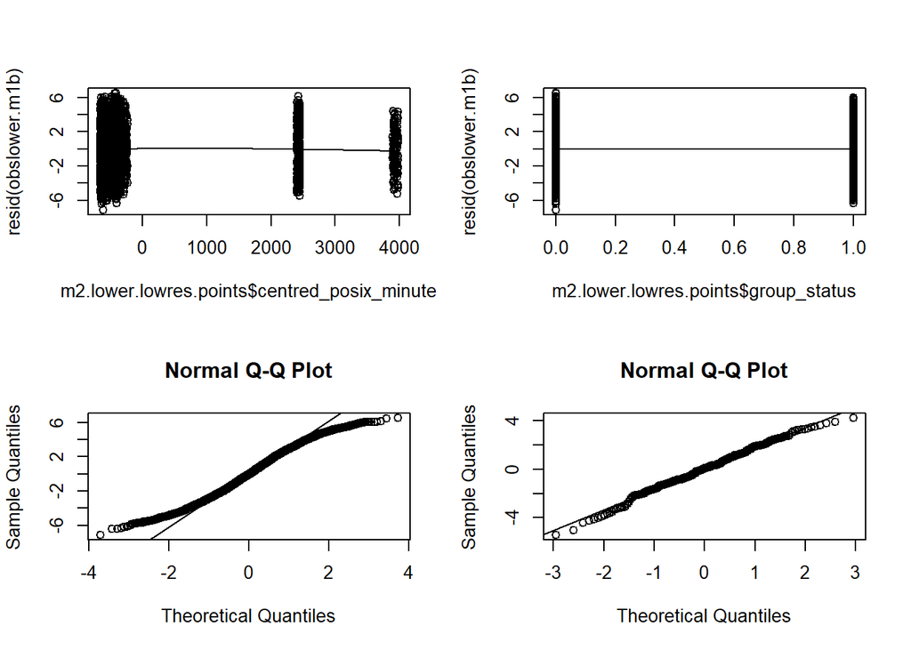

```r
# this chunk checks if the estimates still hold true when the large residuals are removed from the data.
# Let's remove all residuals that are out of the 90%ile residual range.
pctile.range <- 0.90
left.point <- (1-pctile.range)*0.5
pctile.points <- c(left.point, 1-left.point)
m2.general.residuals <- max(abs(quantile(resid(obslower.m1),pctile.points)))
m2.rows.lowres.points <- abs(resid(obslower.m1)) < m2.general.residuals
m2.lower.lowres.points <- obslowerfreq.nona[m2.rows.lowres.points,]

# fit Model 1 with the subset
obslower.m1b <- lmer(lowerfreqkhz ~ group_status + (1|video_annot_id),
                     data=m2.lower.lowres.points)

frame()
par(mfrow=c(2,2))
scatter.smooth(m2.lower.lowres.points$centred_posix_minute,resid(obslower.m1b))
scatter.smooth(m2.lower.lowres.points$group_status,resid(obslower.m1b))
qqnorm(resid(obslower.m1b));qqline(resid(obslower.m1b))
qqnorm(raneffects.m1);qqline(raneffects.m1)
```

### Including virtual multi-bat audio in

```r
obslowerfreq.nona_subset <- obslowerfreq.nona[,c('segment_number','lowerfreqkhz','group_status','rechour','video_annot_id')]
obslowerfreq.nona_subset$group_status <- as.factor(obslowerfreq.nona_subset$group_status*1)
virt_lowerfreq_subset <- virt_lowerfreq[,c('segment_number','lowerfreqkhz','rechour','video_annot_id')]
virt_lowerfreq_subset$group_status <- as.factor(2)
obsvirt_lowerfreq <- rbind(obslowerfreq.nona_subset, virt_lowerfreq_subset)
obsvirt_lowerfreq <- obsvirt_lowerfreq[!is.na(obsvirt_lowerfreq$lowerfreqkhz),]

write.csv(obsvirt_lowerfreq, 'obsvirt_lowerfreq.csv')
```

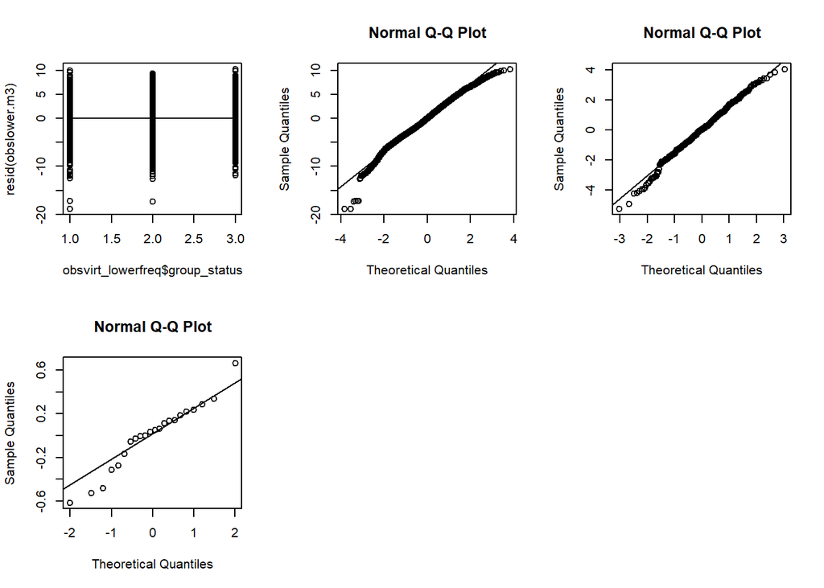

```r
obslower.m3 <- lmer(lowerfreqkhz ~ group_status + (1|rechour)+(1|video_annot_id), data=obsvirt_lowerfreq)
raneffects.m3 <- ranef(obslower.m3)$video_annot_id$'(Intercept)'
raneffects2.m3 <- ranef(obslower.m3)$rechour$'(Intercept)'

frame()
par(mfrow=c(2,3))
#scatter.smooth(obsvirt_lowerfreq$centred_posix_minute,resid(obslower.m3))
scatter.smooth(obsvirt_lowerfreq$group_status,resid(obslower.m3))
qqnorm(resid(obslower.m3));qqline(resid(obslower.m3))
qqnorm(raneffects.m3);qqline(raneffects.m3)
qqnorm(raneffects2.m3);qqline(raneffects2.m3)
```

The assumptions are mostly met - aside from a few points that are *horribly* off. We will also run the regression without these major outliers and see if the model estimates are drastically changed.

```r
obslower.m3b.sim <- sim(obslower.m3, n.sim=num_post)

lowerm3b.hpd.fixefs <- apply(fixef(obslower.m3b.sim),2,get.hpd)

single.lower.b <- fixef(obslower.m3b.sim)[,1]
multi.lower.b <- fixef(obslower.m3b.sim)[,1]+fixef(obslower.m3b.sim)[,2]
virt.lower.b <- fixef(obslower.m3b.sim)[,1]+fixef(obslower.m3b.sim)[,3]


hpd.single.lower.b <- round(get.hpd(single.lower.b),2)
hpd.multi.lower.b <- round(get.hpd(multi.lower.b),2)
hpd.virt.lower.b <- round(get.hpd(virt.lower.b),2)

hpd.multi.single.lowerdiff.b <- round(get.hpd(multi.lower.b-single.lower.b),2)
hpd.multi.virt.lowerdiff.b <- round(get.hpd(multi.lower.b-virt.lower.b),2)


# shape into the table format
multisingle_lowerfreq_mapcoi_diff <- round(get.map.coi(multi.lower.b-single.lower.b),2)
multivirtmulti_lowerfreq_mapcoi_diff <- round(get.map.coi(multi.lower.b-virt.lower.b),2)

multisingle_lowerfreq_mapcoi_ratio <- round(get.map.coi(multi.lower.b/single.lower.b),2)
multivirtmulti_lowerfreq_mapcoi_ratio <- round(get.map.coi(multi.lower.b/virt.lower.b),2)


table_multisingle_lowerfreq <- c('Multi-Single','Lower frequency (kHz)',multisingle_lowerfreq_mapcoi_diff,
                                                                                          multisingle_lowerfreq_mapcoi_ratio)
table_multivirtmulti_lowerfreq <- c('Multi-Virtual multi','Lower frequency (kHz)',multivirtmulti_lowerfreq_mapcoi_diff,
                                                                                          multivirtmulti_lowerfreq_mapcoi_ratio)
table_lowerfreq <- rbind(table_multisingle_lowerfreq,table_multivirtmulti_lowerfreq )

print(table_lowerfreq)
```

```
##                                [,1]                  [,2]                    [,3]    [,4]    [,5]   [,6] [,7]   [,8]
## table_multisingle_lowerfreq    "Multi-Single"        "Lower frequency (kHz)" "-0.25" "-0.82" "0.28" "1"  "0.99" "1"
## table_multivirtmulti_lowerfreq "Multi-Virtual multi" "Lower frequency (kHz)" "-0.41" "-1.2"  "0.37" "1"  "0.99" "1"
```

```r
# table from plots

plotdata_lowerfreq_meancoi <- data.frame(t(unlist(lapply(list(single.lower.b, multi.lower.b, virt.lower.b), get.map.coi ))))
colnames(plotdata_lowerfreq_meancoi) <- c('single-map','single-95hpd-lower','single-95hpd-upper',
                                         'multi-map','multi-95hpd-lower','multi-95hpd-upper',
                                         'virtmulti-map','virtmulti-95hpd-lower','virtmulti-95hpd-upper')
rownames(plotdata_lowerfreq_meancoi) <- c('lowerfreq')
```

Here we see that the lower-frequencies of single, multi and virtual-multi bat audio windows are very similar:

1. Multi-single lower-frequency : the difference is in the range of -0.82 to 0.28 kHz
2. Multi-virtual multi lower-frequency : the difference is in the range of -1.2 to 0.37 kHz

### Lower frequency: analysis with major outliers removed

There were some points that were horribly dealt with by the lower frequency model with all data. What if we remove them – do the estimates change drastically?

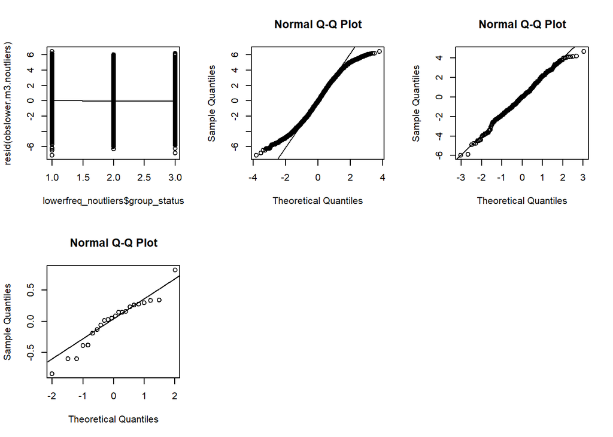

```r
max_resid_threshold <- abs(resid(obslower.m3)) <= quantile(abs(resid(obslower.m3)),0.9)
lowerfreq_noutliers <- obsvirt_lowerfreq[max_resid_threshold,]

obslower.m3.noutliers <- lmer(lowerfreqkhz ~ group_status + (1|rechour)+(1|video_annot_id), data=lowerfreq_noutliers)
raneffects.m3.noutliers <- ranef(obslower.m3.noutliers)$video_annot_id$'(Intercept)'
raneffects2.m3.noutliers <- ranef(obslower.m3.noutliers)$rechour$'(Intercept)'

frame()
par(mfrow=c(2,3))
#scatter.smooth(obsvirt_lowerfreq$centred_posix_minute,resid(obslower.m3.noutliers))
scatter.smooth(lowerfreq_noutliers$group_status,resid(obslower.m3.noutliers))
qqnorm(resid(obslower.m3.noutliers));qqline(resid(obslower.m3.noutliers))
qqnorm(raneffects.m3.noutliers);qqline(raneffects.m3.noutliers)
qqnorm(raneffects2.m3.noutliers);qqline(raneffects2.m3.noutliers)
```

```r
obslower.m3b.noutliers.sim <- sim(obslower.m3.noutliers, n.sim=num_post)

lowerm3b.hpd.fixefs <- apply(fixef(obslower.m3b.noutliers.sim),2,get.hpd)

single.lower.b.noutliers <- fixef(obslower.m3b.noutliers.sim)[,1]
multi.lower.b.noutliers <- fixef(obslower.m3b.noutliers.sim)[,1]+fixef(obslower.m3b.noutliers.sim)[,2]
virt.lower.b.noutliers <- fixef(obslower.m3b.noutliers.sim)[,1]+fixef(obslower.m3b.noutliers.sim)[,3]

# shape into the table format
multisingle_lowerfreq_mapcoi_diff_noutliers <- round(get.map.coi(multi.lower.b.noutliers-single.lower.b.noutliers),2)
multivirtmulti_lowerfreq_mapcoi_diff_noutliers <- round(get.map.coi(multi.lower.b.noutliers-virt.lower.b.noutliers),2)

multisingle_lowerfreq_mapcoi_ratio_noutliers <- round(get.map.coi(multi.lower.b.noutliers/single.lower.b.noutliers),2)
multivirtmulti_lowerfreq_mapcoi_ratio_noutliers <- round(get.map.coi(multi.lower.b.noutliers/virt.lower.b.noutliers),2)


table_multisingle_lowerfreq_noutliers <- c('Multi-Single','Lower frequency (kHz)',multisingle_lowerfreq_mapcoi_diff_noutliers,
                                                                                          multisingle_lowerfreq_mapcoi_ratio_noutliers)

table_multivirtmulti_lowerfreq_noutliers <- c('Multi-Virtual multi','Lower frequency (kHz)',multivirtmulti_lowerfreq_mapcoi_diff_noutliers,
                                                                                          multivirtmulti_lowerfreq_mapcoi_ratio_noutliers)
table_lowerfreq_noutliers <- rbind(table_multisingle_lowerfreq_noutliers,table_multivirtmulti_lowerfreq_noutliers )

print(table_lowerfreq_noutliers)
```

```
##                                          [,1]                  [,2]                    [,3]    [,4]    [,5]   [,6] [,7]   [,8]
## table_multisingle_lowerfreq_noutliers    "Multi-Single"        "Lower frequency (kHz)" "-0.34" "-0.93" "0.26" "1"  "0.99" "1"
## table_multivirtmulti_lowerfreq_noutliers "Multi-Virtual multi" "Lower frequency (kHz)" "-0.43" "-1.32" "0.47" "1"  "0.99" "1.01"
```

## Dominant frequency range

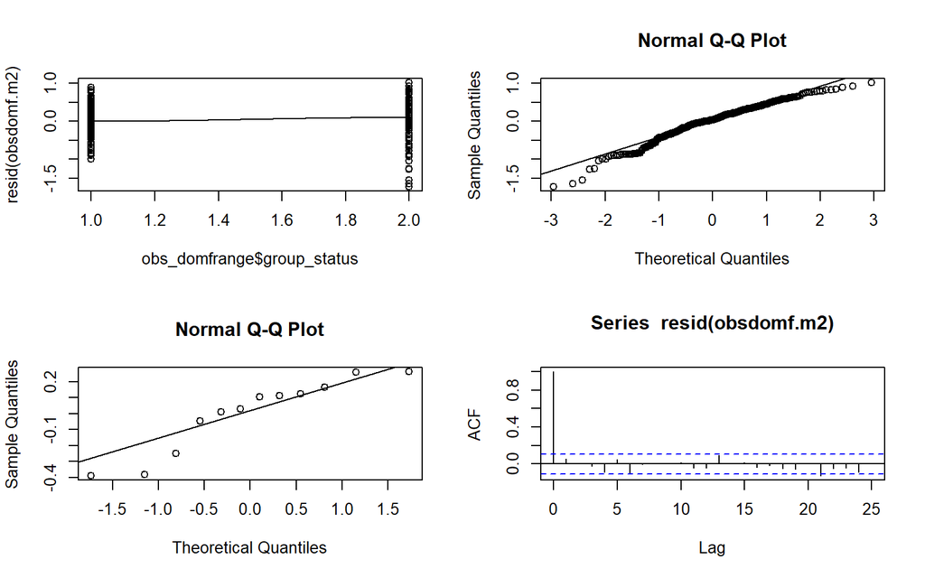

```r
obs_domfrange$sqrt.frange <- sqrt(obs_domfrange$domfrange)
virt_domfrange$sqrt.frange <- sqrt(virt_domfrange$domfrange)
obsdomf.m2 <- lmer(sqrt.frange ~ group_status + (1|rechour), data=obs_domfrange)

raneffect.m2 <-  ranef(obsdomf.m2)$rechour$'(Intercept)'



par(mfrow=c(2,2))
#scatter.smooth(obsvirt_lowerfreq$centred_posix_minute,resid(obslower.m3.noutliers))
scatter.smooth(obs_domfrange$group_status,resid(obsdomf.m2))
qqnorm(resid(obsdomf.m2));qqline(resid(obsdomf.m2))
qqnorm(raneffect.m2);qqline(raneffect.m2)
acf(resid(obsdomf.m2))
```

Here we won’t be using video annotation ID as a random intercept as there is only measurement per annotation ID. Instead I have included the recording hour as a random intercept, and also present the auto-correlation of the residuals to pick up on any correlation in residuals. The autocorrelation plot suggests there is no reason to be concerned about correlation in the data. The residuals aren’t too ideal, but they’re also not too bad either?

```r
obsdomf.m2.sim <- sim(obsdomf.m2, n.sim=num_post)
m2.domf.hpd.fixefs <- apply(fixef(obsdomf.m2.sim),2,get.hpd)


# remember to square the predictions to get the units back to domfreqrange kHz from\
# sqrt(domfreqrange)
single.domf <- (fixef(obsdomf.m2.sim)[,1])^2
multi.domf <- (fixef(obsdomf.m2.sim)[,1]+fixef(obsdomf.m2.sim)[,2])^2
hpd.single.domf <- round(get.hpd(single.domf),2)
hpd.multi.domf <- round(get.hpd(multi.domf),2)

# the final expected multi-single rec-level difference
hpd.multi.single.diff <- round(get.hpd(multi.domf-single.domf),2)
hpd.multi.single.ratio <- round(get.hpd(multi.domf/single.domf),2)
```

### Including virtual audio

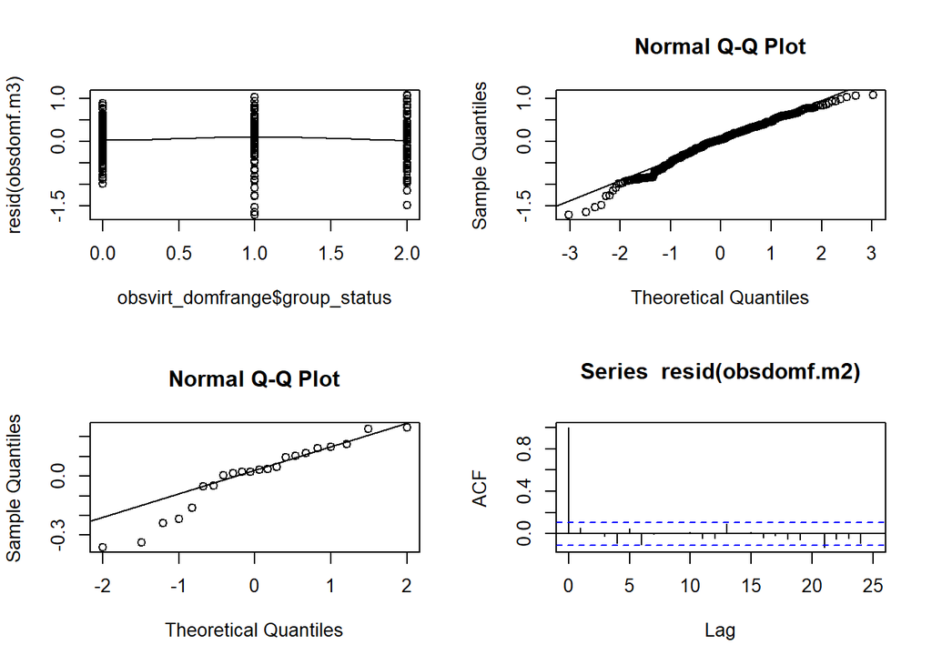

```r
obsvirt_domfrange <- rbind(virt_domfrange[,c('domfrange','group_status','sqrt.frange','rechour')],
                           obs_domfrange[,c('domfrange','group_status','sqrt.frange','rechour')])
obsdomf.m3 <- lmer(sqrt.frange ~ group_status + (1|rechour),data=obsvirt_domfrange)

raneffect.m2 <-  ranef(obsdomf.m3)$rechour$'(Intercept)'



par(mfrow=c(2,2))
#scatter.smooth(obsvirt_lowerfreq$centred_posix_minute,resid(obslower.m3.noutliers))
scatter.smooth(obsvirt_domfrange$group_status,resid(obsdomf.m3))
qqnorm(resid(obsdomf.m3));qqline(resid(obsdomf.m3))
qqnorm(raneffect.m2);qqline(raneffect.m2)
acf(resid(obsdomf.m2))
```

```r
write.csv(obsvirt_domfrange, 'obsvirt_domfrange.csv')
```

```r
obsdomf.m3.sim <- sim(obsdomf.m3, n.sim=num_post)
m3.domf.hpd.fixefs <- apply(fixef(obsdomf.m3.sim),2,get.hpd)
mean.time.effect <- mean(fixef(obsdomf.m3.sim)[,3])

# remember to square the predictions to get the units back to domfreqrange kHz from\
# sqrt(domfreqrange)
single.domfreq <- (fixef(obsdomf.m3.sim)[,1])^2
multi.domfreq <- (fixef(obsdomf.m3.sim)[,1]+fixef(obsdomf.m3.sim)[,2])^2
virt.domfreq <- (fixef(obsdomf.m3.sim)[,1]+fixef(obsdomf.m3.sim)[,3])^2


# shape into the table format
multisingle_domfreq_mapcoi_diff_ <- round(get.map.coi(multi.domfreq -single.domfreq),2)
multivirtmulti_domfreq_mapcoi_diff_ <- round(get.map.coi(multi.domfreq-virt.domfreq),2)

multisingle_domfreq_mapcoi_ratio_ <- round(get.map.coi(multi.domfreq/single.domfreq),2)
multivirtmulti_domfreq_mapcoi_ratio_ <- round(get.map.coi(multi.domfreq/virt.domfreq),2)


table_multisingle_domfreq_ <- c('Multi-Single','Dominant frequency range (kHz)',multisingle_domfreq_mapcoi_diff_,
                                                                                          multisingle_domfreq_mapcoi_ratio_)

table_multivirtmulti_domfreq_ <- c('Multi-Virtual multi','Dominant frequency range (kHz)',multivirtmulti_domfreq_mapcoi_diff_,
                                                                                          multivirtmulti_domfreq_mapcoi_ratio_)
table_domfreq_ <- rbind(table_multisingle_domfreq_,table_multivirtmulti_domfreq_)

print(table_domfreq_)
```

```
##                               [,1]                  [,2]                             [,3]    [,4]   [,5]   [,6]   [,7]   [,8]
## table_multisingle_domfreq_    "Multi-Single"        "Dominant frequency range (kHz)" "2.14"  "1.74" "2.62" "4.91" "3.48" "6.48"
## table_multivirtmulti_domfreq_ "Multi-Virtual multi" "Dominant frequency range (kHz)" "-0.03" "-0.8" "0.78" "1"    "0.71" "1.29"
```

```r
# plot data mean MAP and CoI

plotdata_domfreq_meancoi <- data.frame(t(unlist(lapply(list(single.domfreq, multi.domfreq, virt.domfreq), get.map.coi ))))
colnames(plotdata_domfreq_meancoi) <- c('single-map','single-95hpd-lower','single-95hpd-upper',
                                         'multi-map','multi-95hpd-lower','multi-95hpd-upper',
                                         'virtmulti-map','virtmulti-95hpd-lower','virtmulti-95hpd-upper')
rownames(plotdata_domfreq_meancoi) <- c('domfreq')
```

```r
num.files <- function(X){length(unique(X$video_annot_id))}
num.windows <- function(X){length(unique(X$windowid))}
# dominant frequency
domfreq.samplesizes <- data.frame(table(obsvirt_domfrange$group_status))
domfreq.samplesizes[,1] <- c('single','multi','virtual-multi')
colnames(domfreq.samplesizes) <- c('group-status','sample-size')

# Received level
n_windows_reclevel <- table(obsvirt_reclevel$group_status)
n_files_reclevel <- by(obsvirt_reclevel, obsvirt_reclevel$group_status, num.files)

# lower frequency
obsvirt_lowerfreq$windowid <- do.call(paste0, obsvirt_lowerfreq[c("video_annot_id", "segment_number")])
n_msmts_lowerfreq <- table(obsvirt_lowerfreq$group_status)
n_windows_lowerfreq <- by(obsvirt_lowerfreq, obsvirt_lowerfreq$group_status, num.windows)
n_files_lowerfreq <- by(obsvirt_lowerfreq, obsvirt_lowerfreq$group_status, num.files)
```

## Summarised results

```r
library(flextable)

# put it all together

# received level
all_params <- rbind(table_reclevel, table_lowerfreq, table_domfreq_)
colnames(all_params) <- c('Comparison', 'Parameter', 'Difference-(MAP)', 'Lower-95%CoI', 'Upper-95%CoI','Ratio-(MAP)','Lower-95%CoI', 'Upper-95%CoI')

write.csv(all_params, 'window-analysis-table.csv')

flextable(data.frame(all_params))
```

| Comparison | Parameter | Difference..MAP. | Lower.95.CoI | Upper.95.CoI | Ratio..MAP. | Lower.95.CoI.1 | Upper.95.CoI.1 |
| --- | --- | --- | --- | --- | --- | --- | --- |
| Multi-Single | Received level (dB RMS) | 0.2 | -0.4 | 0.9 | - | - | - |
| Multi-Virtual multi | Received level (dB RMS) | 0.5 | -0.4 | 1.4 | - | - | - |
| Multi-Single | Lower frequency (kHz) | -0.25 | -0.82 | 0.28 | 1 | 0.99 | 1 |
| Multi-Virtual multi | Lower frequency (kHz) | -0.41 | -1.2 | 0.37 | 1 | 0.99 | 1 |
| Multi-Single | Dominant frequency range (kHz) | 2.14 | 1.74 | 2.62 | 4.91 | 3.48 | 6.48 |
| Multi-Virtual multi | Dominant frequency range (kHz) | -0.03 | -0.8 | 0.78 | 1 | 0.71 | 1.29 |

```r
# here put together the mean MAP and CoI for the windowed analysis measurements + results

windowed_analysis_mapcoi <- rbind(round(plotdata_domfreq_meancoi,2), round(plotdata_lowerfreq_meancoi,2), round(plotdata_reclevel_meancoi,1))

write.csv(windowed_analysis_mapcoi, 'windowed_mean-map-coi-table.csv')
```

## References

Gelman, Andrew, and Sander Greenland. 2019. “Are Confidence Intervals Better Termed ‘Uncertainty Intervals’?” *BMJ* 366.

McElreath, Richard. 2020. *Statistical Rethinking: A Bayesian Course with Examples in r and Stan*. CRC press.